# Logistic Regression

김권현

2018년 11월 18일

### 결과가 ’0 또는 1’과 같이 이산 분포일 때 선형 회귀 모형으로 분석할 때 문제점

- $\beta_1 \neq 0$인 경우 예측변수에 커지거나 작아지면 예측값이 0보다 작거나, 1보다 커진다.
- $Y|x$의 분포는 정규분포가 아니다.

## 로지스틱 회귀분석

### 로지스틱의 가정

- **L**inearity : $g(\mathbb{E}[Y|x])$는 계수의 선형함수이다.
- **I**ndependence : $x$가 주어졌을 때, $Y$의 분포는 서로 독립이다.
- **N**ormality : 오차의 분포는 이항분포이다. 일반화 선형모형(GLM; Generalized Linear Model)에서는 $Y|x$의 분포가 이항분포, 다항분포, 푸와송 분포 등으로 확장된다.
- **E**qual Variance : 오차의 분산은 오차의 분포에 따라 예측 변수 값에 따라 달라질 수 있다.

#### 몇 가지 용어

- 승산(odds) : 어떤 사건의 확률이 $p$일 때, 승산은 $\frac{p}{1-p}$이다.
- 승산비(odds ratio) : 두 사건의 승산의 비율. 한 사건의 확률이 $p_1$이고, 다른 사건의 확률이 $p_2$일 때, 승산비는 $\frac{p_1}{1-p_1}/\frac{p_2}{1-p_2}$이다. 또는 확률의 변화를 나타낼 수도 있다. 확률의 변화를 나타낼 때 승산비는 두 승산의 비율로 생각할 수 있다. 예를 들어 $0.3$의 확률이 $0.5$로 증가했다면, 승산은 $0.3/0.7=0.42$에서 $0.5/0.5=1$로 증가했으면 승산비의 비율은 $1/0.42 = 2.380952$가 된다.
- 로짓(logit) : 로그 승산($\log \frac{p}{1-p}$)
- 로지스틱(logistic) 함수(로짓의 역함수) : $\frac{1}{1+\exp(-x)}$

```r
library(arm)
```

```
## Working directory is /home/master/git/MJU-2018-02-DataScience/00_Instructor/W12_LogisticRegression
```

```
## Working directory is D:/Git/MJU-2018-02-DataScience/00_Instructor/W12_LogisticRegression
```

```r
invlogit
```

[output not shown]

```r
logit
```

[output not shown]

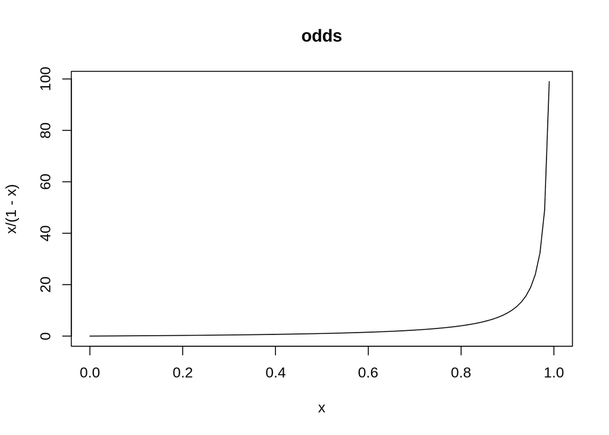

```r
curve(x/(1-x), xlim=c(0,1), main='odds')
```

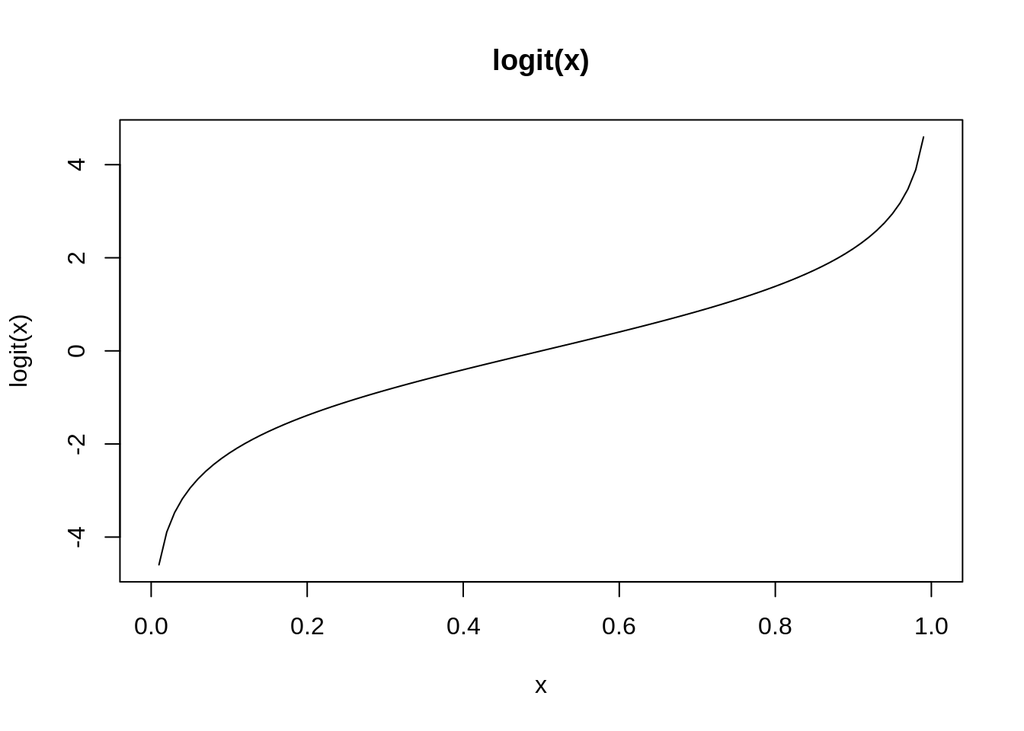

```r
curve(logit(x), xlim=c(0,1), main='logit(x)')
```

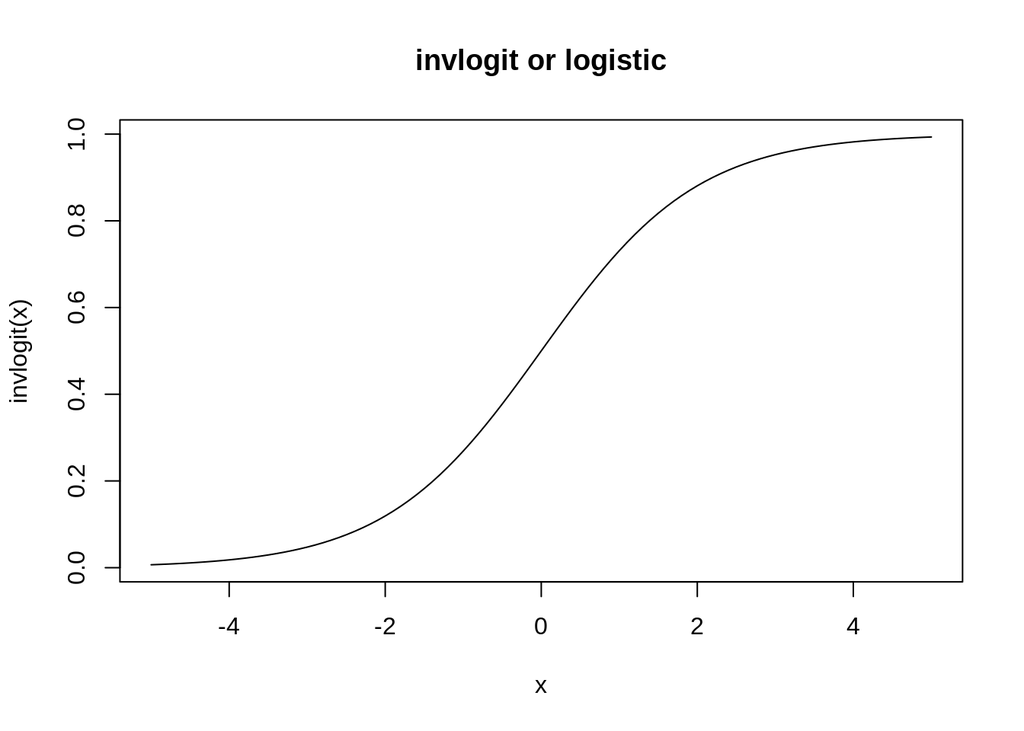

```r
curve(invlogit(x), xlim=c(-5,5), main='invlogit or logistic')
```

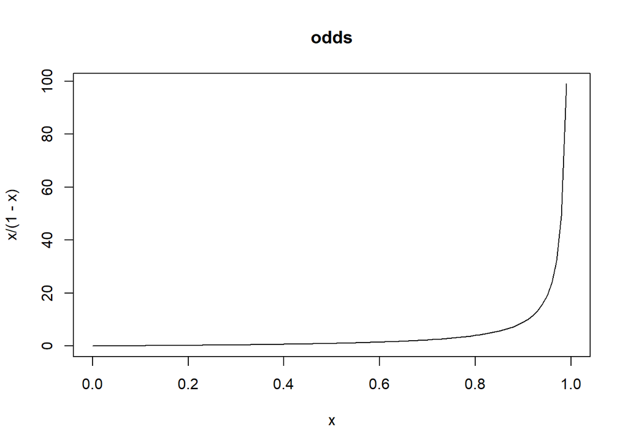

```r
curve(x/(1-x), xlim=c(0,1), main='odds')
```

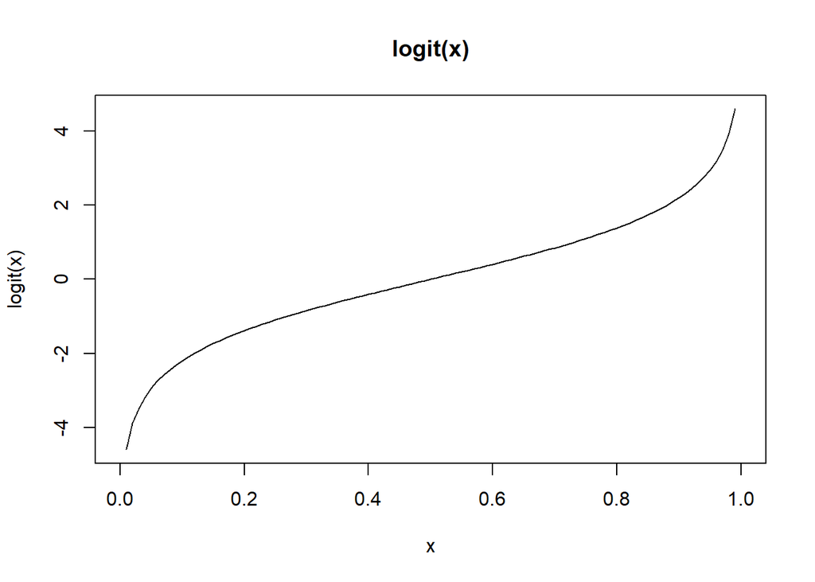

```r
curve(logit(x), xlim=c(0,1), main='logit(x)')
```

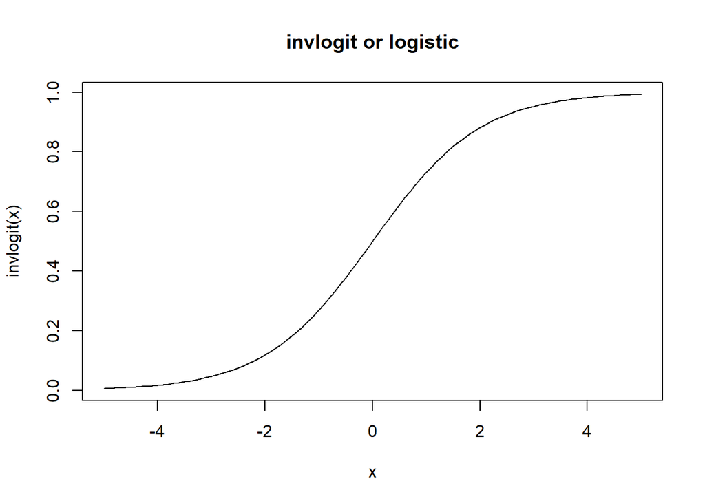

```r
curve(invlogit(x), xlim=c(-5,5), main='invlogit or logistic')
```

### 예 : `carData::Wells`

- 데이터 살펴보기

```r
data(Wells, package='carData')
summary(Wells)
```

```
##  switch        arsenic         distance         education      association
##  no :1283   Min.   :0.510   Min.   :  0.387   Min.   : 0.000   no :1743
##  yes:1737   1st Qu.:0.820   1st Qu.: 21.117   1st Qu.: 0.000   yes:1277
##             Median :1.300   Median : 36.761   Median : 5.000
##             Mean   :1.657   Mean   : 48.332   Mean   : 4.828
##             3rd Qu.:2.200   3rd Qu.: 64.041   3rd Qu.: 8.000
##             Max.   :9.650   Max.   :339.531   Max.   :17.000
```

- 데이터 시각화 1

```r
library(ggplot2)
ggplot(data=Wells) + geom_point(aes(x=distance, y=switch), alpha=0.1)
```

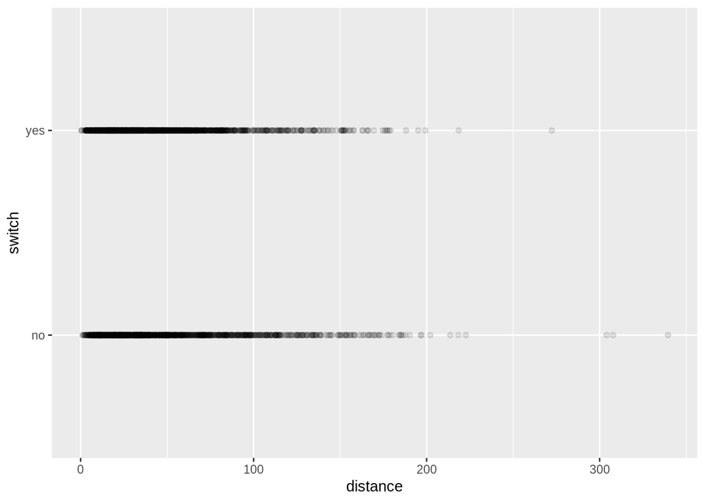

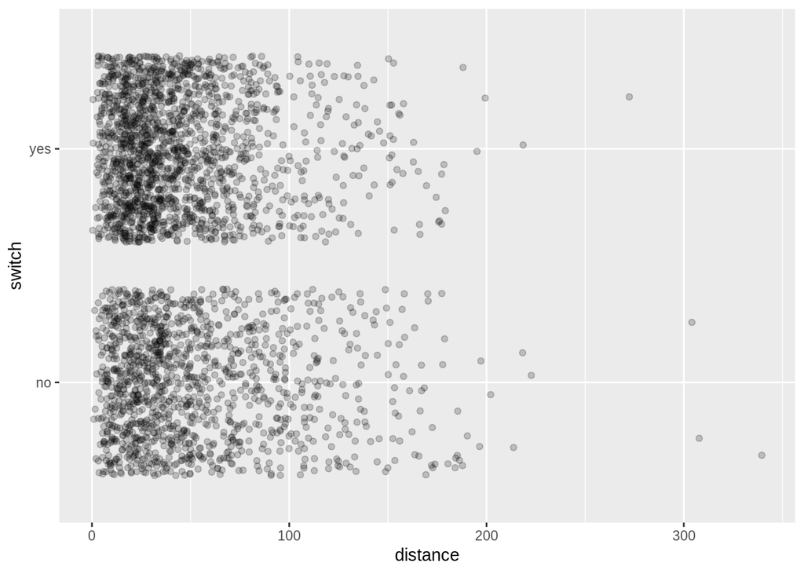

```r
ggplot(data=Wells) + geom_jitter(aes(x=distance, y=switch), alpha=0.2)
```

[figure not shown]

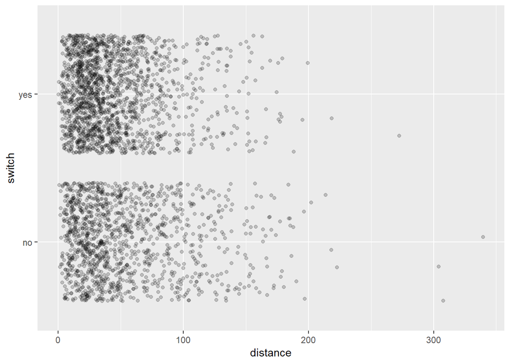

```r
ggplot(data=Wells) + geom_jitter(aes(x=distance, y=switch), alpha=0.2)
```

- 데이터 시각화 2

```r
library(dplyr)
```

```r
Wells_cut <-
  Wells %>% summarise(min = min(distance), max = max(distance), by = (max-min)/10)
Wells <-
  Wells %>% mutate(distCut = cut(distance,
                                 breaks=seq(Wells_cut$min, Wells_cut$max, Wells_cut$by)))
ggplot(data=Wells, aes(x=distCut, col=switch, fill=switch)) + geom_bar()
```

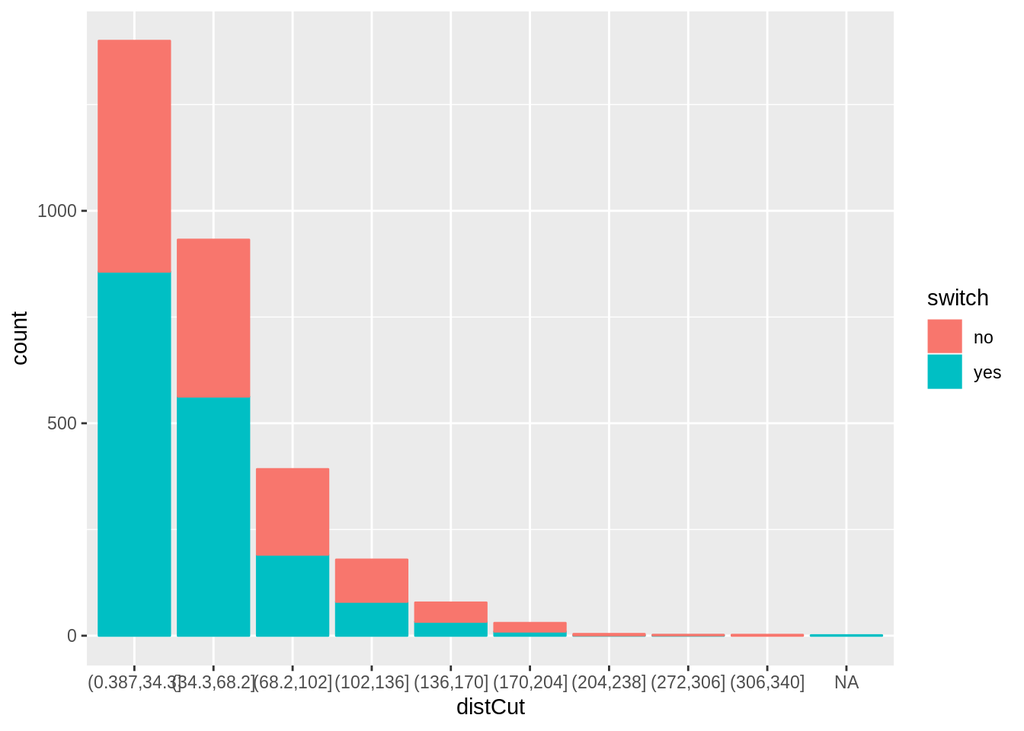

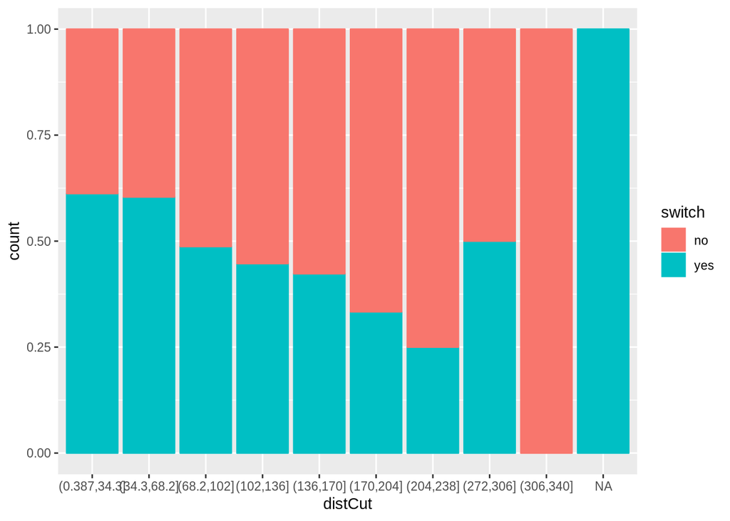

```r
ggplot(data=Wells, aes(x=distCut, col=switch, fill=switch)) + geom_bar(position = "fill" )
```

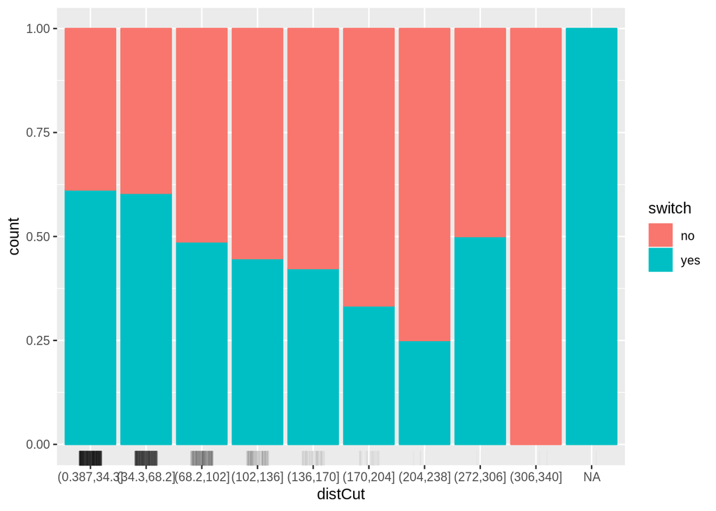

```r
ggplot(data=Wells, aes(x=distCut, col=switch, fill=switch)) + geom_bar(position = "fill" ) +
  geom_rug(aes(x=distCut, y=0.5), position=position_jitter(width=0.2),    alpha=0.02, sides='b', col='black')
```

[figure not shown]

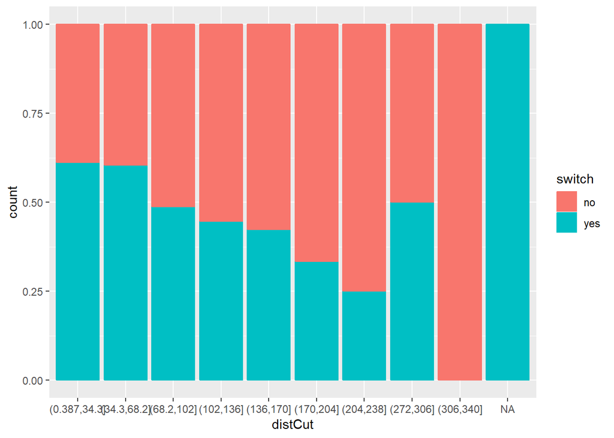

```r
ggplot(data=Wells, aes(x=distCut, col=switch, fill=switch)) + geom_bar(position = "fill" )
```

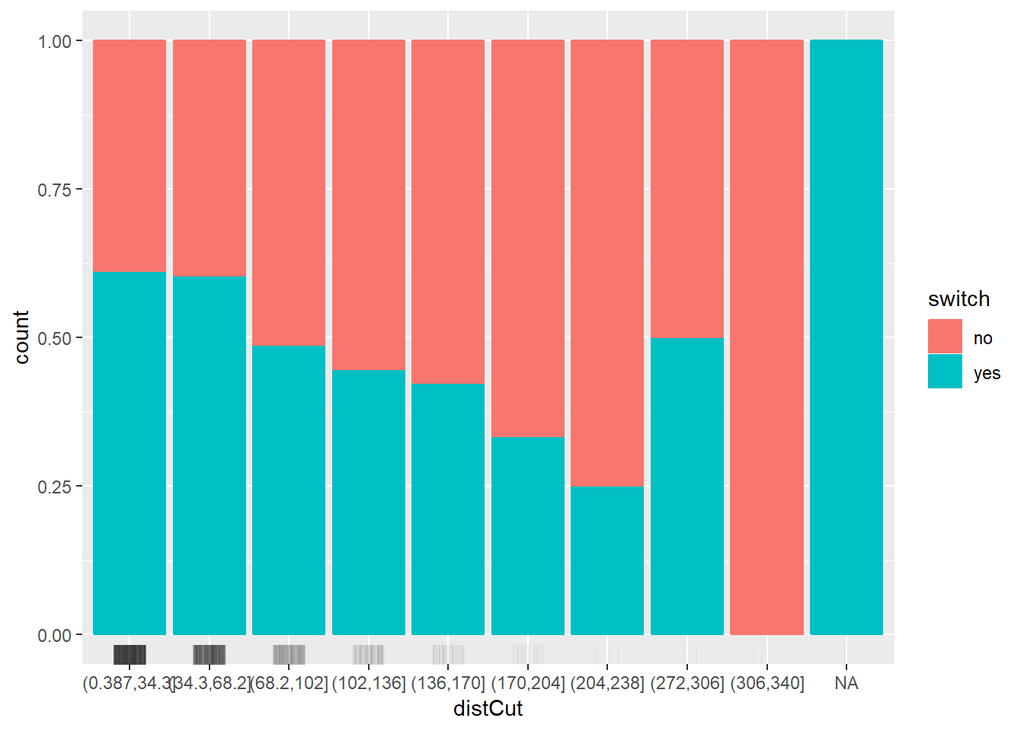

```r
ggplot(data=Wells, aes(x=distCut, col=switch, fill=switch)) + geom_bar(position = "fill" ) +
  geom_rug(aes(x=distCut, y=0.5), position=position_jitter(width=0.2),    alpha=0.02, sides='b', col='black')
```

```r
library(dplyr)
Wells_cut <-
  Wells %>% summarise(min = min(distance), max = max(distance), by = (max-min)/5)
Wells <-
  Wells %>% mutate(distCut = cut(distance,
                                 breaks=seq(Wells_cut$min, Wells_cut$max, Wells_cut$by)))
ggplot(data=Wells, aes(x=distCut, col=switch, fill=switch)) + geom_bar()
```

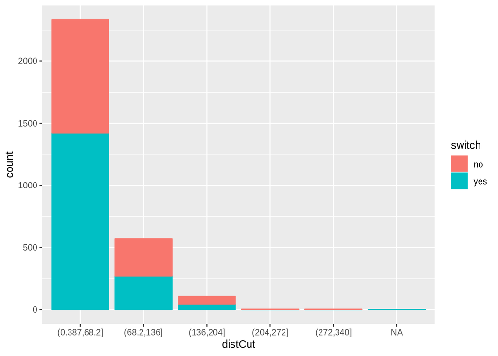

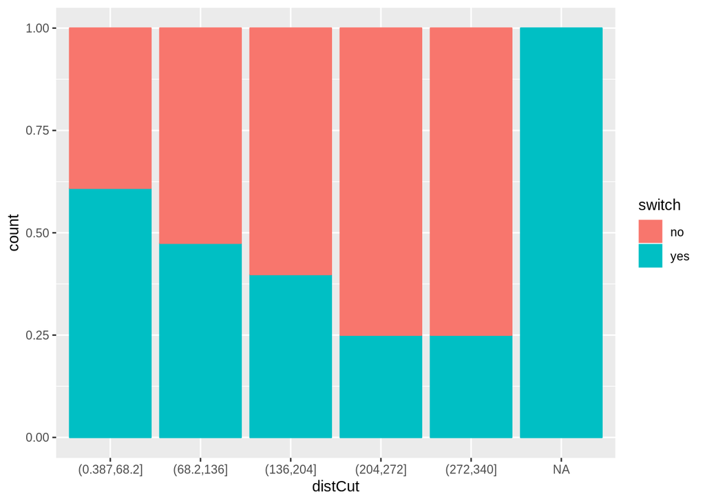

```r
ggplot(data=Wells, aes(x=distCut, col=switch, fill=switch)) + geom_bar(position = "fill" )
```

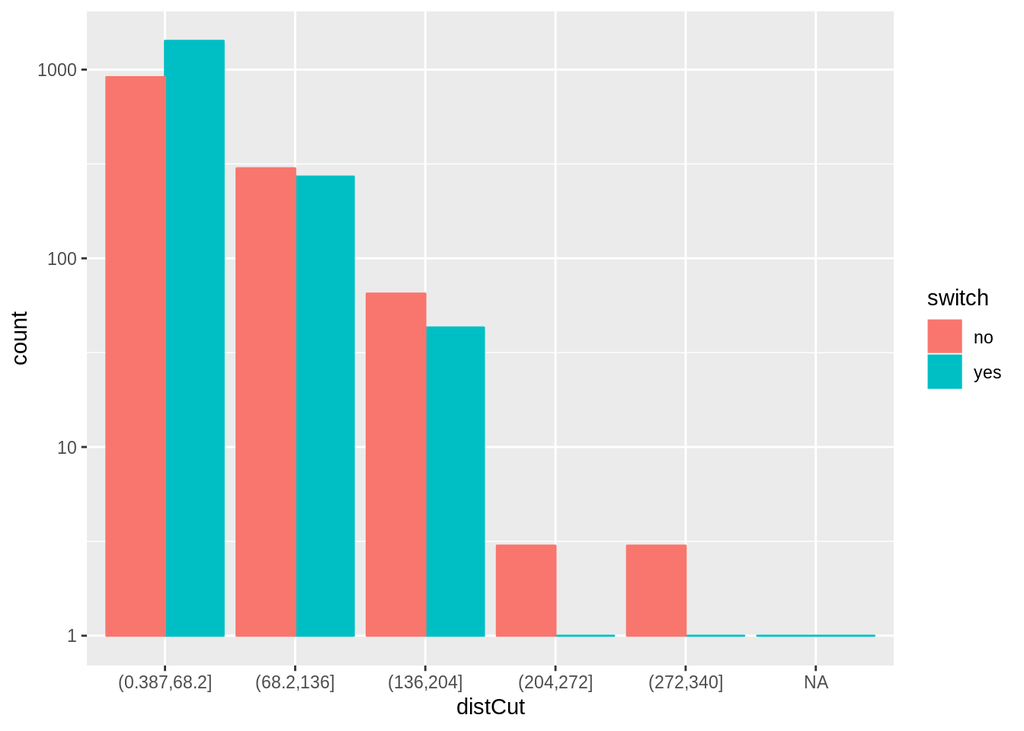

```r
ggplot(data=Wells, aes(x=distCut, col=switch, fill=switch)) + geom_bar(position = "dodge" ) +
  scale_y_log10()
```

[figure not shown]

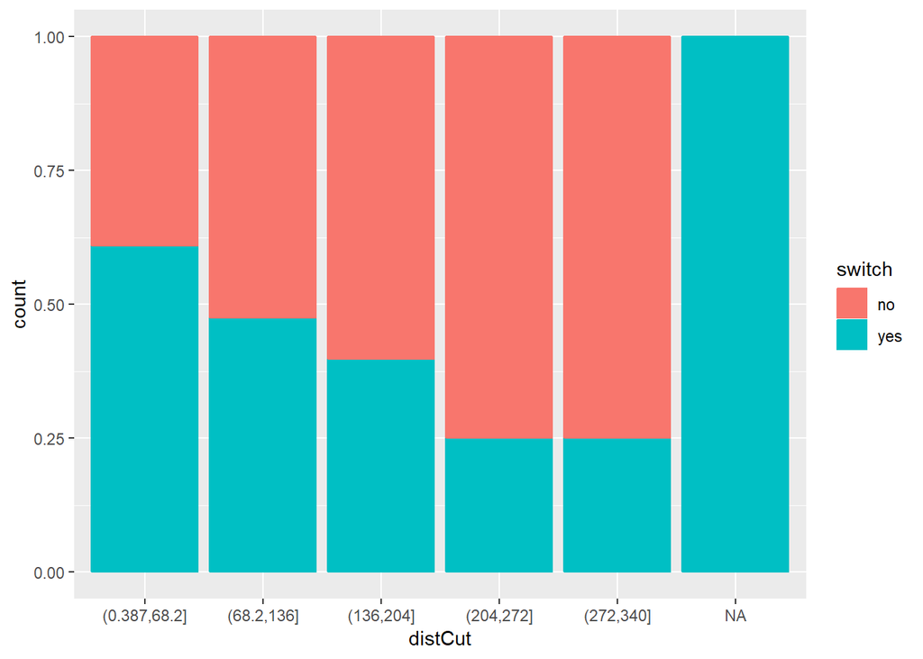

```r
ggplot(data=Wells, aes(x=distCut, col=switch, fill=switch)) + geom_bar(position = "fill" )
```

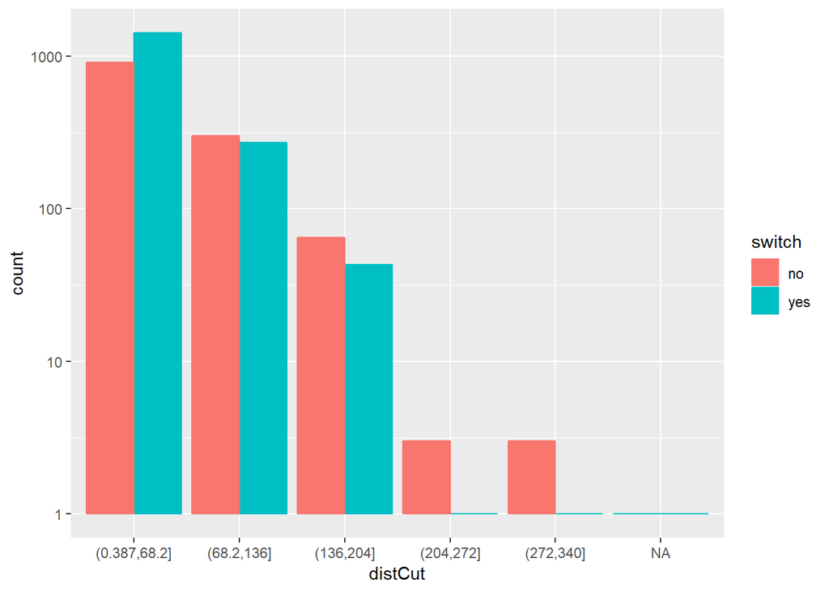

```r
ggplot(data=Wells, aes(x=distCut, col=switch, fill=switch)) + geom_bar(position = "dodge" ) +
  scale_y_log10()
```

- 로지스틱 회귀분석

```r
fit0 <- glm(switch ~ distance, family=binomial(link="logit"),
            data=Wells)
fit0 # 계수 및 model fit(Null Deviance, Residual Deviance, AIC) 확인
```

```
##
## Call:  glm(formula = switch ~ distance, family = binomial(link = "logit"),
##     data = Wells)
##
## Coefficients:
## (Intercept)     distance
##    0.605959    -0.006219
##
## Degrees of Freedom: 3019 Total (i.e. Null);  3018 Residual
## Null Deviance:       4118
## Residual Deviance: 4076  AIC: 4080
```

- 로지스틱 회귀분석 계수의 해석
  - 로짓(logit)은 선형적이다.
  - $x$의 수준에 따라 $x$의 영향이 달라진다.
  - [로지스틱 회귀에서 계수는 예측변수 1 증가에 따른 두 승산의 승산비로 해석할 수 있다.](https://bookdown.org/jefftemplewebb/IS-6489/logistic-regression.html) ($\frac{p_2/(1-p_2)}{p_1/(1-p_1)} = \exp(\beta_1)$)

```r
summary(fit0)
```

```
##
## Call:
## glm(formula = switch ~ distance, family = binomial(link = "logit"),
##     data = Wells)
##
## Deviance Residuals:
##     Min       1Q   Median       3Q      Max
## -1.4406  -1.3058   0.9669   1.0308   1.6603
##
## Coefficients:
##               Estimate Std. Error z value Pr(>|z|)
## (Intercept)  0.6059594  0.0603102  10.047  < 2e-16 ***
## distance    -0.0062188  0.0009743  -6.383 1.74e-10 ***
## ---
## Signif. codes:  0 '***' 0.001 '**' 0.01 '*' 0.05 '.' 0.1 ' ' 1
##
## (Dispersion parameter for binomial family taken to be 1)
##
##     Null deviance: 4118.1  on 3019  degrees of freedom
## Residual deviance: 4076.2  on 3018  degrees of freedom
## AIC: 4080.2
##
## Number of Fisher Scoring iterations: 4
```

```r
coef(fit0)
```

```
##  (Intercept)     distance
##  0.605959365 -0.006218819
```

```r
confint(fit0)
```

```
##                    2.5 %       97.5 %
## (Intercept)  0.488223018  0.724681386
## distance    -0.008140762 -0.004319795
```

```r
newdat = data.frame(distance = seq(0, 500, 10))
predy <- predict(fit0, newdata=newdat, type='link', se.fit=TRUE)
head(predy) # predy$fit, $se.fit,
```

```
## $fit
##           1           2           3           4           5           6
##  0.60595937  0.54377117  0.48158298  0.41939478  0.35720659  0.29501839
##           7           8           9          10          11          12
##  0.23283020  0.17064201  0.10845381  0.04626562 -0.01592258 -0.07811077
##          13          14          15          16          17          18
## -0.14029897 -0.20248716 -0.26467535 -0.32686355 -0.38905174 -0.45123994
##          19          20          21          22          23          24
## -0.51342813 -0.57561633 -0.63780452 -0.69999272 -0.76218091 -0.82436910
##          25          26          27          28          29          30
## -0.88655730 -0.94874549 -1.01093369 -1.07312188 -1.13531008 -1.19749827
##          31          32          33          34          35          36
## -1.25968646 -1.32187466 -1.38406285 -1.44625105 -1.50843924 -1.57062744
##          37          38          39          40          41          42
## -1.63281563 -1.69500382 -1.75719202 -1.81938021 -1.88156841 -1.94375660
##          43          44          45          46          47          48
## -2.00594480 -2.06813299 -2.13032118 -2.19250938 -2.25469757 -2.31688577
##          49          50          51
## -2.37907396 -2.44126216 -2.50345035
##
## $se.fit
##          1          2          3          4          5          6
## 0.06031022 0.05296506 0.04650923 0.04136128 0.03805573 0.03708851
##          7          8          9         10         11         12
## 0.03863564 0.04242292 0.04792214 0.05461863 0.06212643 0.07018567
##         13         14         15         16         17         18
## 0.07862697 0.08733961 0.09624994 0.10530779 0.11447815 0.12373600
##         19         20         21         22         23         24
## 0.13306309 0.14244581 0.15187386 0.16133928 0.17083587 0.18035871
##         25         26         27         28         29         30
## 0.18990384 0.19946806 0.20904876 0.21864376 0.22825127 0.23786977
##         31         32         33         34         35         36
## 0.24749797 0.25713480 0.26677930 0.27643069 0.28608825 0.29575140
##         37         38         39         40         41         42
## 0.30541959 0.31509236 0.32476931 0.33445007 0.34413432 0.35382177
##         43         44         45         46         47         48
## 0.36351217 0.37320529 0.38290092 0.39259887 0.40229898 0.41200110
##         49         50         51
## 0.42170508 0.43141080 0.44111814
##
## $residual.scale
## [1] 1
```

```r
prob = 0.95
predy$lwr <- predy$fit + qnorm((1-prob)/2)*predy$se.fit
predy$upr <- predy$fit + qnorm(1-(1-prob)/2)*predy$se.fit

dfPredy <- data.frame(predy)
dfPredy$distance <- newdat$distance

library(arm)
dfPredy <-
  dfPredy %>% mutate(lwr = invlogit(lwr),
                     upr = invlogit(upr),
                     fit = invlogit(fit))
```

- 로지스틱 회귀분석 시각화

```r
library(effects)
```

```r
eff <- effect("distance", fit0)
plot(eff, type='response') # type = "rescale", "response", "link"
```

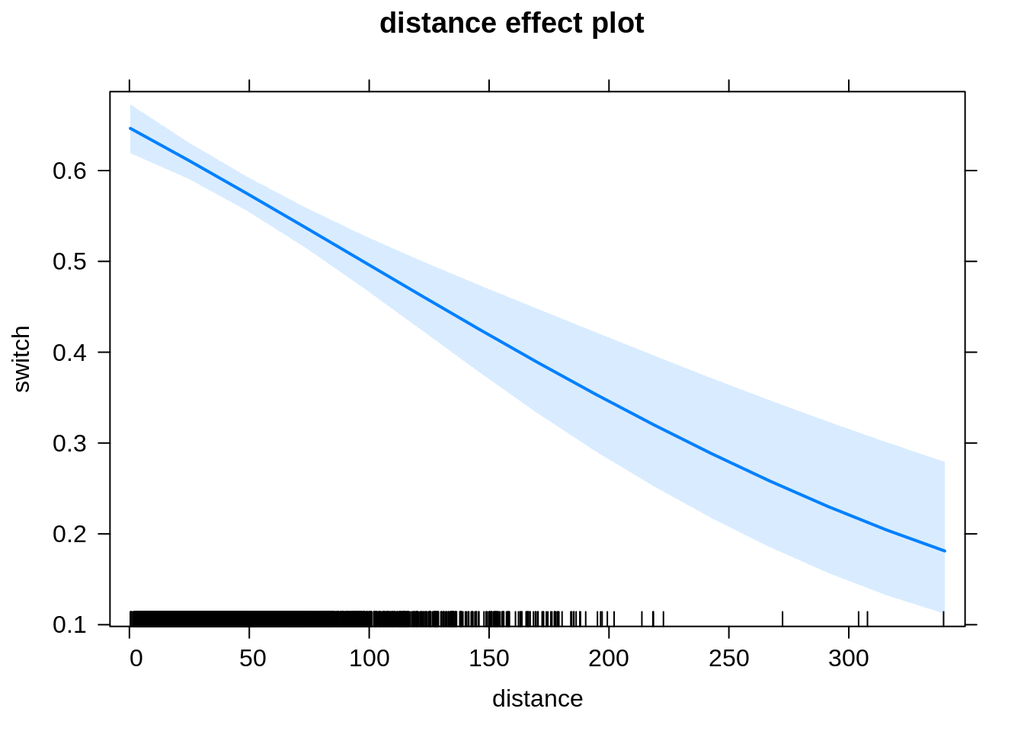

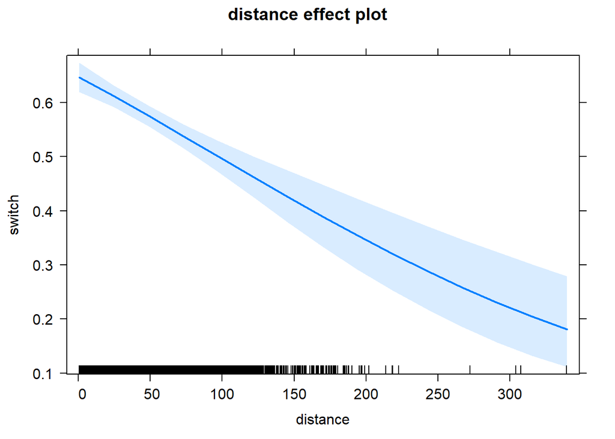

```r
#plot(eff, family="bionomial")

#effAll <- allEffects(fit0)
#plot(effAll, type='response')

Wells <- Wells %>% mutate(switchnum = ifelse(switch=="yes", 1, 0))
ggplot(data=Wells) + geom_jitter(aes(x=distance, y=switchnum), alpha=0.2, height=0.05) +
  geom_line(data=dfPredy, aes(x=distance, y=fit)) +
  geom_ribbon(data=dfPredy %>% arrange(distance), aes(x=distance, y=fit, ymin=lwr, ymax=upr), alpha=0.2)
```

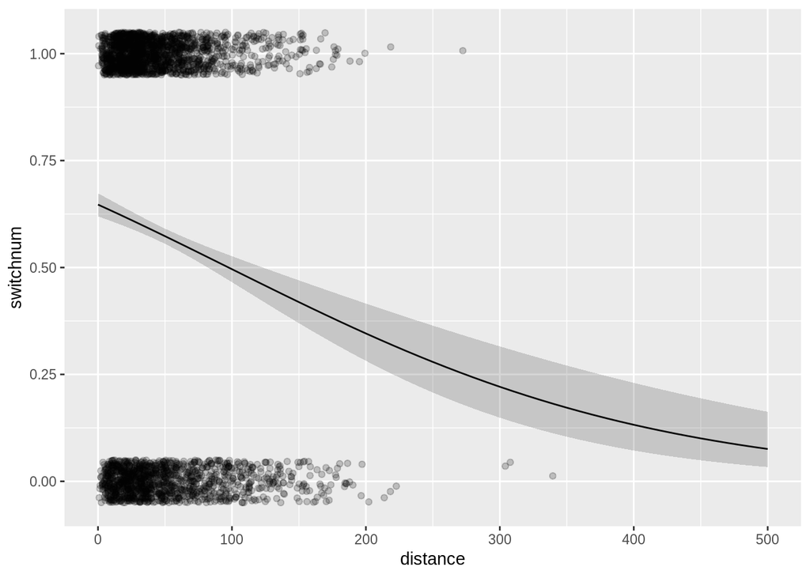

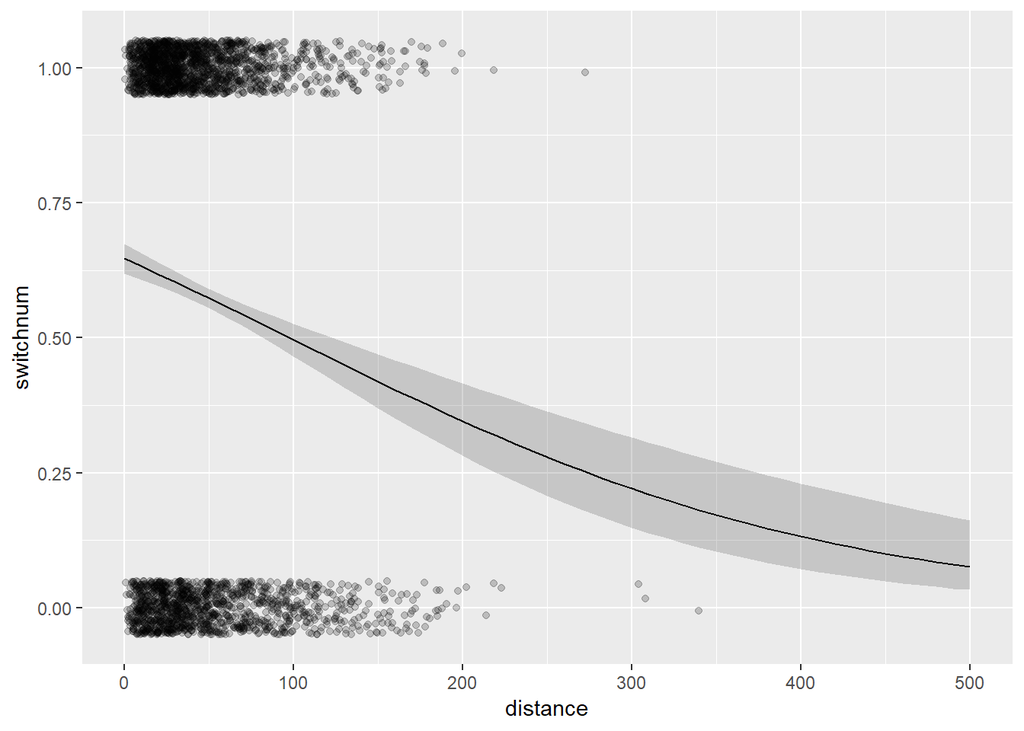

```r
#ggplot(data=Wells) + geom_jitter(aes(x=distance, y=switchnum), alpha=0.2, height=0.05) +
#  geom_line(data=dfPredy, aes(x=distance, y=fit)) +
#  geom_ribbon(data=dfPredy %>% arrange(distance), aes(x=distance, y=fit, ymin=lwr, ymax=upr), alpha=0.2) +
#  xlim(-100, 500)
```